# Simulation Design

#### 4. single actor belief development ( actor 0)

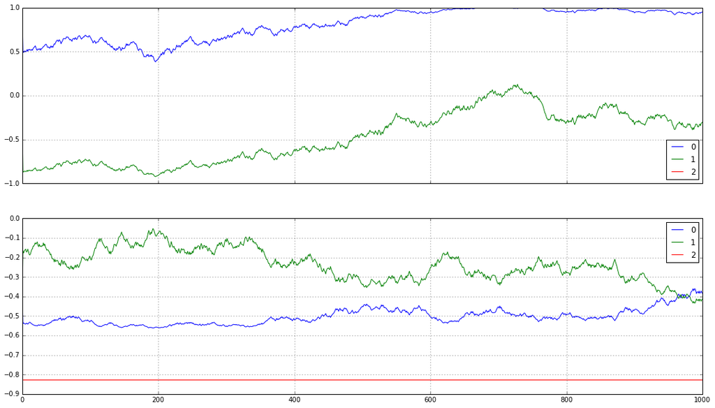

```python
s.visualizer.visualize_actor_belief_longitudinal(0)
```

#### 5. BeliefNetwork

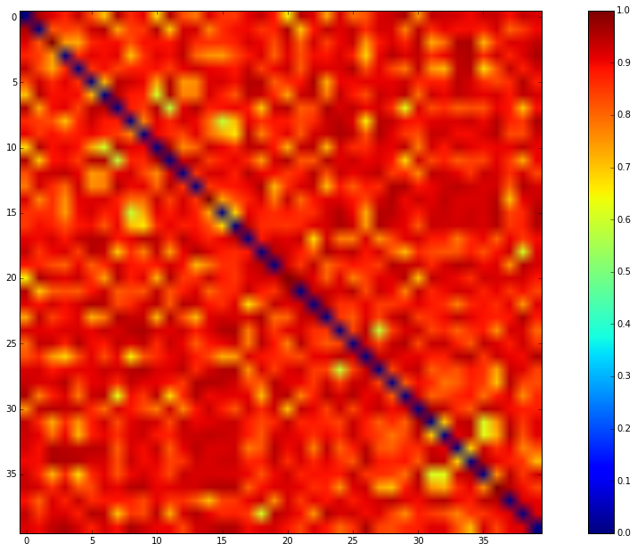

```python
s.visualizer.visualize_Network_heatmap(s.society.BeliefNetwork)
```

Comments: the proximity is calculated from distance matrix with sigmoid function, by adjusting the decay parameter of sigmoid function the heatmap can look different, but seems the distinguishability is not enough here (diagonal represents elligibility, not proximity)

#### 6. BallotHistoryNetwork

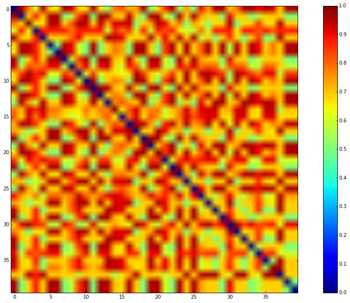

```python
s.visualizer.visualize_Network_heatmap(s.society.BallotHistoryNetwork)
```

#### 7. DelegationNetwork

```python
g = ig.Graph.TupleList(s.society.votes, directed=True)
layout = g.layout('kk')
ig.plot(g, layout = layout)
```

[figure not shown]

## 2. Representative

```python
# two constituencies, one with 70 people, the other with 30
group_dict = {0:70,1:30}
# two topics, the first one with 2 policies, the second one with 3 policies
topic_dict = {0:2,1:3}
param_dict = {'a':1/4.0,'alpha':np.pi/100,
              'belta':0.1, 'numCandidate':4,'numDelegator':3,
              'electionPeriod':365, 'ballotPeriod':100,
              'sigmoid_decay':0.8}

socialism_dict = {'vote_func':vote_representative}
sim_params_representative = [group_dict, topic_dict, param_dict, socialism_dict]
```

```python
sim_params_representative
```

```
[{0: 70, 1: 30},
 {0: 2, 1: 3},
 {'a': 0.25,
  'alpha': 0.031415926535897934,
  'ballotPeriod': 100,
  'belta': 0.1,
  'electionPeriod': 365,
  'numCandidate': 4,
  'numDelegator': 3,
  'sigmoid_decay': 0.8},
 {'vote_func': <function representative.vote_representative>}]
```

```python
s = Simulator(sim_params_representative)
s.simul(1000)
```

```
---Election---
---Ballot---
---Ballot---
---Ballot---
---Election---
---Ballot---
---Ballot---
---Ballot---
---Ballot---
---Election---
---Ballot---
---Ballot---
---Ballot---
running time: 34.2637190819 seconds
--------------- System Status --------------------
nsteps: 1000
number of Actors: 100
Ballot History: [[1.0, 0.0], [1.0, 0.0], [1.0, 0.0], [0.0, 1.0], [0.0, 1.0], [0.0, 0.0], [0.0, 0.0], [1.0, 1.0], [1.0, 0.0], [1.0, 0.0]]
delegatiors: [2, 5, 66, 80, 90, 97]
--------------- Actor Profile --------------------
actor identification: 0
actor motivation: 0.0889488788075
actor belief: [array([ 0.03194902, -0.9994895 ]), array([-0.08133913, -0.93761792,  0.33801861])]
actor groupId: 0
actor delegation status: 0
actor candidate status: 0
actor motivation history(short view first 10 time stamps):
[0.088948878807528955, 0.088948878807528955, 0.088948878807528955, 0.088948878807528955, 0.088948878807528955, 0.088948878807528955, 0.088948878807528955, 0.088948878807528955, 0.088948878807528955, 0.088948878807528955]

actor belief history:
[[array([ 0.03194902, -0.9994895 ]), array([-0.08133913, -0.93761792,  0.33801861])], [array([ 0.26107262, -0.96531916]), array([-0.31488398, -0.88689994,  0.33801861])], [array([ 0.25375648, -0.96726814]), array([-0.33700796, -0.8787315 ,  0.33801861])], [array([ 0.27393194, -0.96174908]), array([-…

actor ballot history:
[[0.0, 2.0], [0.0, 2.0], [0.0, 2.0], [0.0, 2.0], [0.0, 2.0], [0.0, 2.0], [0.0, 2.0], [0.0, 2.0], [0.0, 2.0], [0.0, 2.0]]
```

#### 1. cross sectional population motivation distribution

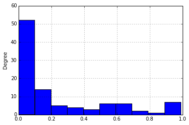

```python
s.visualizer.visualize_population_motivation()
```

#### 2. cross sectional population belief

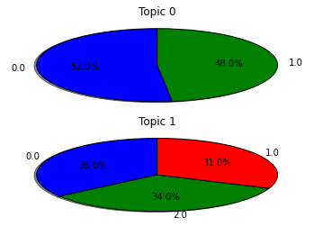

```python
s.visualizer.visualize_population_beliefs()
```

#### 3. single actor motivation development ( actor 0)

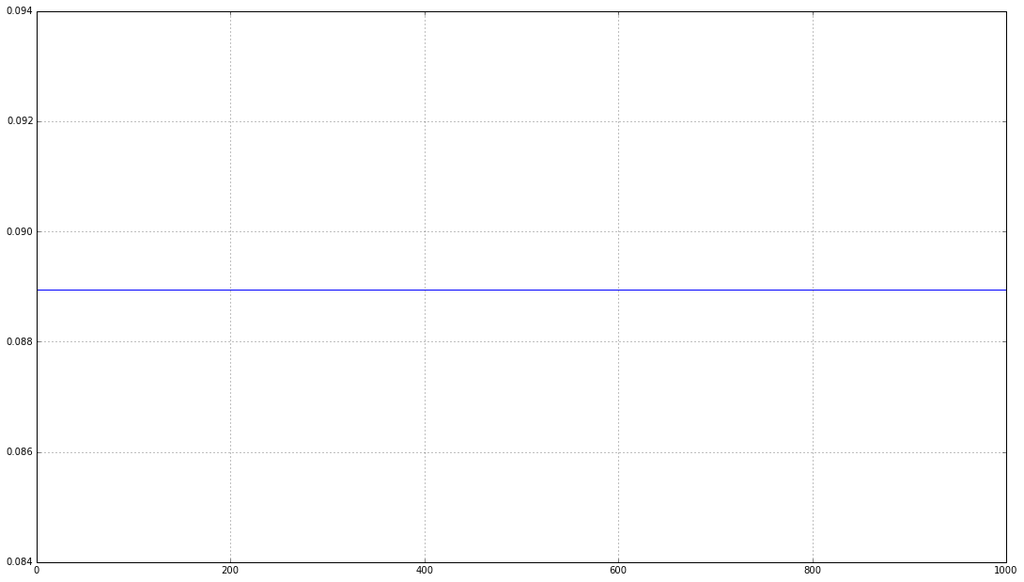

```python
s.visualizer.visualize_actor_motivation_longitudinal(0)
```

#### 4. single actor belief development ( actor 0)

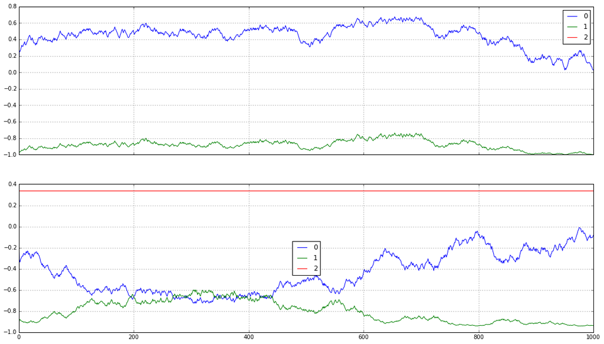

```python
s.visualizer.visualize_actor_belief_longitudinal(0)
```

#### 5. BeliefNetwork

Comment: BeliefNerwork is diagnal blocks which show the fact that voting cross group does not happen

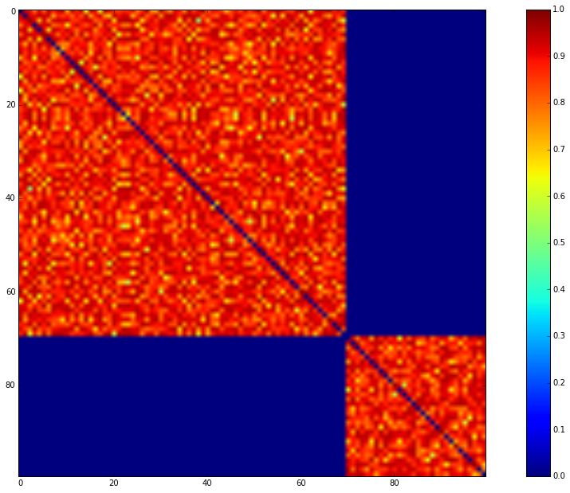

```python
s.visualizer.visualize_Network_heatmap(s.society.BeliefNetwork)
```

#### 6 BallotHistoryNetwork

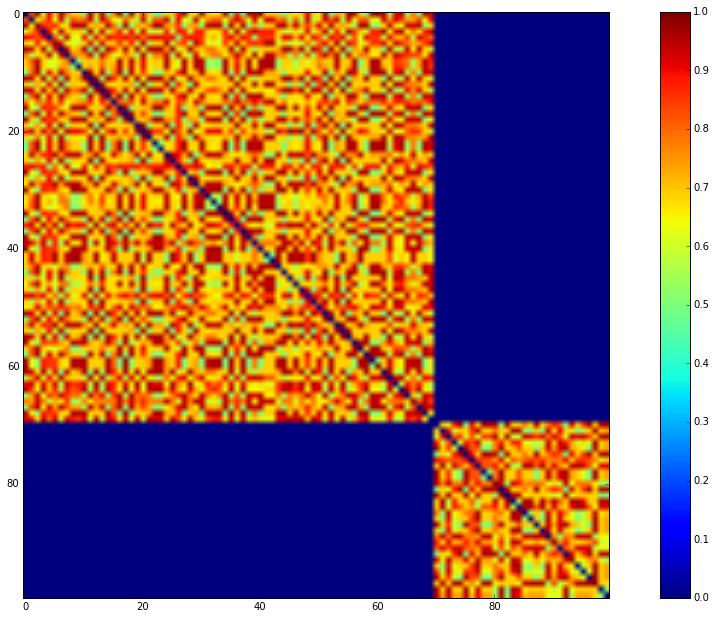

```python
s.visualizer.visualize_Network_heatmap(s.society.BallotHistoryNetwork)
```

#### 7. DelegationNetwork

Comment: actor to candidate has maximal path length 1

```python
g = ig.Graph.TupleList(s.society.votes, directed=True)
layout = g.layout('kk')
ig.plot(g, layout = layout)
```

[figure not shown]

### Short Terms Plan TODOs on this project

- implement liquid democracy type 2 ?
- doing unit test on important functions to enhance the reliability of the code ?
- enable **random change** and **triggered change** on motivation ?
- try to study a little bit the proper distance function and proximity mapping ?